# Predicting Red & White - Matthew Lipinski

Import cleaned dataset “WineMag”

[output not shown]

```r
install.packages("party")
library(partykit)
```

Factoring variables for certain models.

```r
WMDT <- data.frame(country = as.factor(c(WineMag$Country)),
                   continent = as.factor(c(Continents$Cdf)),
                   description = as.factor(c(WineMag$Description)),
                   designation = as.factor(c(WineMag$Designation)),
                   points = as.factor(c(WineMag$Points)),
                   price = as.factor(c(WineMag$Price)),
                   province = as.factor(c(WineMag$Province)),
                   region_1 = as.factor(c(WineMag$Region_1)),
                   region_2 = as.factor(c(WineMag$Region_2)),
                   variety = as.factor(c(WineMag$Variety)),
                   winery = as.factor(c(WineMag$Winery)),
                   redness = as.numeric(c(WnMg2$Redness)),
                   whiteness = as.numeric(c(WnMg2$Whiteness)),
                   cluster = as.factor(c(WnMg2$Cluster)),
                   newPrice = as.factor(c(WMDT14$newPrice)),
                   newPoints = as.factor(c(WMDT13$newPoints)),
                   newRegion = as.factor(c(Regions$Regiondf))
                   )
```

Remove rows without a red or white score.

```r
WMDT2.1 <- WMDT[!rowSums(WMDT[, c(12,13)]) == 0, ]
```

Create a dataset WMDT with points binned in 4 groups that now includes 13 attributes.

```r
WMDT13 <- mutate(WMDT, newPoints = ifelse(points %in% 80:84, "80-84",
                                     ifelse(points %in% 85:89, "85-89",
                                     ifelse(points %in% 90:94, "90-94",
                                     ifelse(points %in% 95:100, "95-100", "Other")))))
```

Create new dataframe with numeric and factors.

```r
WMDT22 <- data.frame(clusters = as.factor(clusters2$Cluster),
                     region = as.factor(Regions$Regiondf),
                     points = as.numeric(as.character(WMDT$points)),
                     price = as.numeric(as.character(WMDT$price))
                     )
```

```r
summary(WMDT22)
```

[output not shown]

Install packages necessary for decision tree and training and test datasets.

```r
library(ROCR)
```

Create train and test datasets.

```r
samp_size <- floor(0.7 *nrow(WMDT22))
set.seed(2015)
train_ind <- sample(seq_len(nrow(WMDT22)), size = samp_size)
train <- WMDT22[train_ind, ]
test <- WMDT22[-train_ind, ]
```

Edit controls in rpart tuning and run decsion tree on training.

```r
start.time <- Sys.time()
ttt <- rpart.control(1000, cp = 0.005)
train22 <- rpart(clusters ~ price + points, method = "class", data = train, control = ttt )
time.taken <- Sys.time() - start.time
cat("Duration", time.taken, " seconds")
```

```
Duration 0.9811721  seconds
```

Review rpart on train.

```r
printcp(train22)
```

```
Classification tree:
rpart(formula = clusters ~ price + points, data = train, method = "class",
    control = ttt)

Variables actually used in tree construction:
[1] price

Root node error: 31140/62382 = 0.49918

n= 62382

       CP nsplit rel error  xerror      xstd
1 0.17039      0   1.00000 1.00812 0.0040103
2 0.00500      1   0.82961 0.83003 0.0039510
```

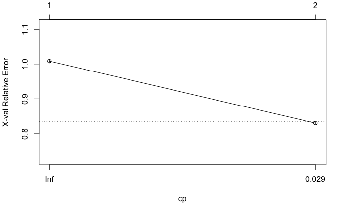

```r
plotcp(train22)
```

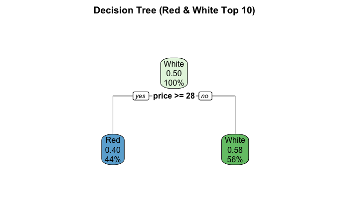

```r
rpart.plot(train22, uniform = TRUE, main = "Decision Tree (Red & White Top 10)")
```

Decision tree on test and provide the accuracy score.

```r
test22 <- predict(train22, test)
conf.matrix22 <- table(predict(train22, test, type = "class"), test$clusters)
rownames(conf.matrix22) <- paste("Actual", rownames(conf.matrix22), sep = ": ")
colnames(conf.matrix22) <- paste("Predicted", colnames(conf.matrix22), sep = ": ")
conf.matrix22
```

```
                Predicted: Red Predicted: White
  Actual: Red             6892             4790
  Actual: White           6422             8632
```

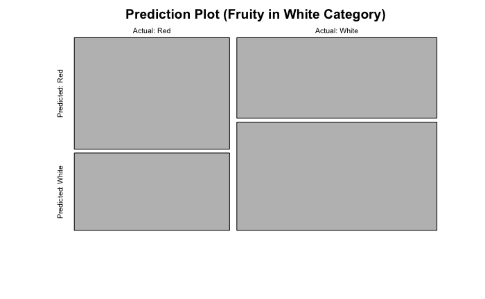

```r
plot(conf.matrix22, main = "Prediction Plot (Fruity in White Category)")
```

```r
TPTN <- conf.matrix22[1,1] + conf.matrix22[2,2]
TotalSum <- (conf.matrix22[1,1] + conf.matrix22[1,2] + conf.matrix22[2,1] + conf.matrix22[2,2])
Accuracy1 <- TPTN / TotalSum
Accuracy1
```

```
[1] 0.5806403
```

Check to see if Random Forest model does better job of predicting red and white wines.

Install Random Forest package and library.

```r
library(randomForest)
```

Run random forest on training dataset.

```r
start.time <- Sys.time()
fitRF <- randomForest(as.factor(clusters) ~ price + points + region,
                      data = train,
                      importance = TRUE,
                      ntree = 10)
```

[output not shown]

Review the significance of the chosen predictors.

[figure not shown]

```r
varImpPlot(fitRF)
```

Run the Random Forest on the test dataset, review the results, confusion matrix, and accuracy.

```r
RFresults <- predict(fitRF, test)
conf.matrixRF <- table(predict(fitRF, test, type = "class"), test$clusters)
rownames(conf.matrixRF) <- paste("Actual", rownames(conf.matrixRF), sep = ": ")
colnames(conf.matrixRF) <- paste("Predicted", colnames(conf.matrixRF), sep = ": ")
conf.matrixRF
```

```
                Predicted: Red Predicted: White
  Actual: Red             6902             4810
  Actual: White           6412             8612
```

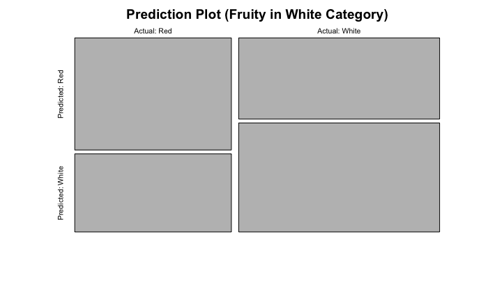

```r
plot(conf.matrixRF, main = "Prediction Plot (Fruity in White Category)")
```

Since random forest didn’t produce better results, let’s see if Naive Bayes can improve things.

Naive Bayes

```r
install.packages("naivebayes")
library(naivebayes)
```

Test Naive Bayes

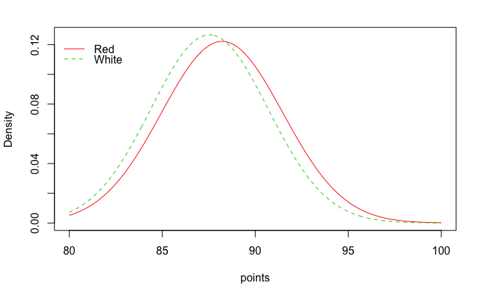

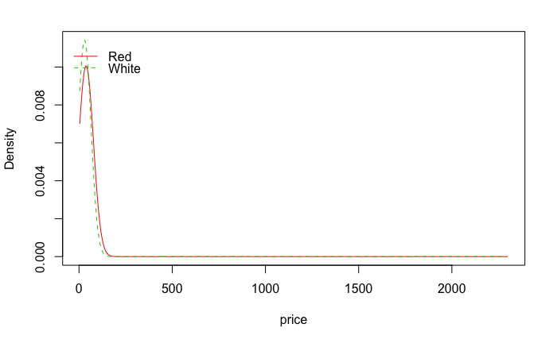

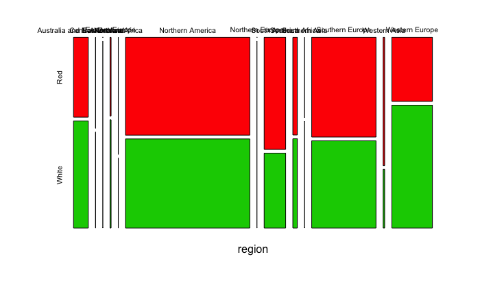

```r
NB <- naive_bayes(clusters ~ points + price + region, data = train)
predictNB <- predict(NB, test)
CMNB <- table(predictNB <- predict(NB, test, type = "class"), test$clusters)
plot(NB)
```

```r
CMNB
```

```
         Red White
  Red   5997  3530
  White 7317  9892
```

```r
TPTNnb <- CMNB[1,1] + CMNB[2,2]
TotalSumnb <- (CMNB[1,1] + CMNB[1,2] + CMNB[2,1] + CMNB[2,2])
Accuracynb <- TPTNnb / TotalSumnb
Accuracynb
```

```
[1] 0.5942923
```

Take 2

Our choice of Red and White words are subjective and seeing if we change the words that are in each group, we can see if this is truly the reason our first model is so inconsistent.

Create new dataframe with numeric and factors.

```r
WMDT33 <- data.frame(clusters = as.factor(clusters2T2$Cluster),
                     region = as.factor(Regions$Regiondf),
                     points = as.numeric(as.character(WMDT$points)),
                     price = as.numeric(as.character(WMDT$price))
                     )
```

Change clusters from 1 and 2 to Red and White.

```r
WMDT33 <- data.frame(clusters = as.numeric(clusters2T2$Cluster),
                     region = as.factor(Regions$Regiondf),
                     points = as.numeric(as.character(WMDT$points)),
                     price = as.numeric(as.character(WMDT$price))
                     )
WMDT33$clusters[WMDT33$clusters == "1"] <- "Red"
WMDT33$clusters[WMDT33$clusters == "2"] <- "White"
```

Create train and test datasets.

```r
samp_sizeT2 <- floor(0.7 *nrow(WMDT33))
set.seed(2015)
train_ind <- sample(seq_len(nrow(WMDT33)), size = samp_sizeT2)
trainT2 <- WMDT33[train_ind, ]
testT2 <- WMDT33[-train_ind, ]
```

Decsion tree on training.

```r
start.time <- Sys.time()
train33 <- rpart(clusters ~ price + points, method = "class", data = trainT2)
time.taken <- Sys.time() - start.time
cat("Duration", time.taken, " seconds")
```

```
Duration 0.458354  seconds
```

Review rpart on train.

```r
printcp(train33)
```

```
Classification tree:
rpart(formula = clusters ~ price + points, data = trainT2, method = "class")

Variables actually used in tree construction:
character(0)

Root node error: 22913/68495 = 0.33452

n= 68495

  CP nsplit rel error xerror xstd
1  0      0         1      0    0
```

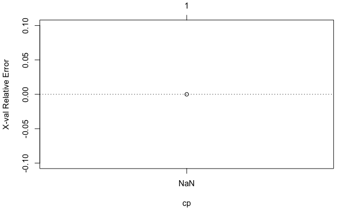

```r
plotcp(train33)
```

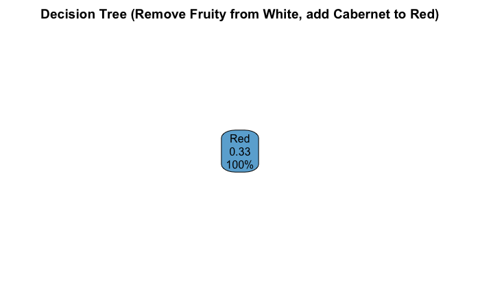

```r
rpart.plot(train33, uniform = TRUE, main = "Decision Tree (Remove Fruity from White, add Cabernet to Red)")
```

Decision tree on test.

```r
test33 <- predict(train33, testT2)
conf.matrix33 <- table(predict(train33, testT2, type = "class"), testT2$clusters)
rownames(conf.matrix33) <- paste("Actual", rownames(conf.matrix33), sep = ": ")
colnames(conf.matrix33) <- paste("Predicted", colnames(conf.matrix33), sep = ": ")
conf.matrix33
```

```
                Predicted: Red Predicted: White
  Actual: Red            19454             9902
  Actual: White              0                0
```

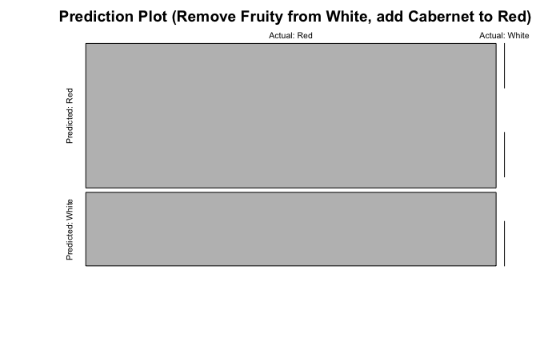

```r
plot(conf.matrix33, main = "Prediction Plot (Remove Fruity from White, add Cabernet to Red)")
```

```r
TPTNnb33 <- conf.matrix33[1,1] + conf.matrix33[2,2]
TotalSumnb33 <- (conf.matrix33[1,1] + conf.matrix33[1,2] + conf.matrix33[2,1] + conf.matrix33[2,2])
Accuracynb33 <- TPTNnb33 / TotalSumnb33
Accuracynb33
```

```
[1] 0.6626925
```

Additional code that we ended up not utilizing for our project, but keeping as there is some useful code and concepts.

Decsion tree.

```r
start.time <- Sys.time()
fit22 <- rpart(clusters ~ price + points, method = "class", data = WMDT22)
time.taken <- Sys.time() - start.time
cat("Duration", time.taken, " seconds")
```

```
Duration 1.432778  seconds
```

Review rpart.

```r
printcp(fit22)
```

```
Classification tree:
rpart(formula = clusters ~ price + points, data = WMDT22, method = "class")

Variables actually used in tree construction:
[1] price

Root node error: 48411/97851 = 0.49474

n= 97851

       CP nsplit rel error  xerror      xstd
1 0.15509      0   1.00000 1.00000 0.0032306
2 0.01000      1   0.84491 0.84551 0.0031874
```

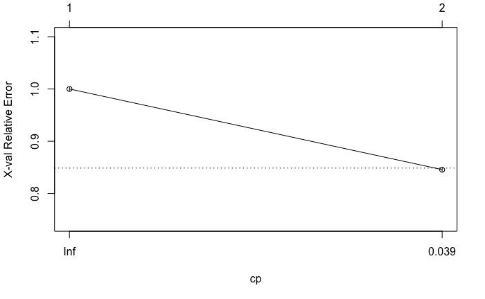

```r
plotcp(fit22)
```

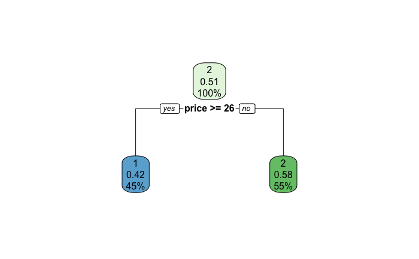

```r
rpart.plot(fit22, uniform = TRUE)
```

Binning of prices.

```r
WMDT14 <- mutate(WMDT13, newPrice = ifelse(price %in% 0:24, "0 - 24",
                                    ifelse(price %in% 25:49, "25-49",
                                    ifelse(price %in% 50:74, "50-74",
                                    ifelse(price %in% 75:99, "75-99",
                                    ifelse(price %in% 100:124, "100-124",
                                    ifelse(price %in% 125:149, "125-149",
                                    ifelse(price %in% 150:174, "150-174",
                                    ifelse(price %in% 175:199, "175-199",
                                    ifelse(price %in% 200:249, "200-249",
                                    ifelse(price %in% 250:299, "250-299",
                                    ifelse(price %in% 300:399, "300-399",
                                    ifelse(price %in% 400:499, "400-499",
                                    ifelse(price %in% 500:999, "500-999",
                                    ifelse(price %in% 1000:1999, "1,000-1,999",
                                    ifelse(price %in% 2000:2500, "2,000-2,500",
                                           "Other"))))))))))))))))
```

```r
DTdf <- cbind.data.frame(WMDT2.1$newRegion, WMDT2.1$newPrice, WMDT2.1$newPoints, WMDT2.1$cluster)
colnames(DTdf) <- c("Regions", "PriceBin", "PointsBin", "Clusters")
```

Attempt to create a decision tree using rpart.

```r
start.time <- Sys.time()
fit11 <- rpart(Clusters ~ PointsBin, method = "class", data = DTdf)
time.taken <- Sys.time() - start.time
cat("Duration", time.taken, " seconds")
```

```
Duration 0.582444  seconds
```

Review rpart.

```r
printcp(fit11)
```

```
Classification tree:
rpart(formula = Clusters ~ PointsBin, data = DTdf, method = "class")

Variables actually used in tree construction:
[1] PointsBin

Root node error: 43255/91666 = 0.47188

n= 91666

        CP nsplit rel error  xerror      xstd
1 0.012762      0   1.00000 1.00000 0.0034942
2 0.010000      1   0.98724 0.99801 0.0034938
```

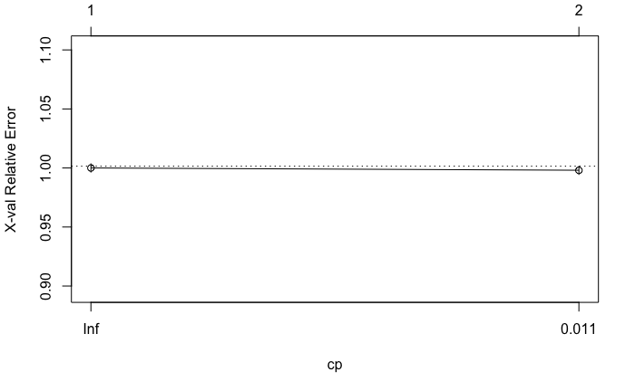

```r
plotcp(fit11)
```

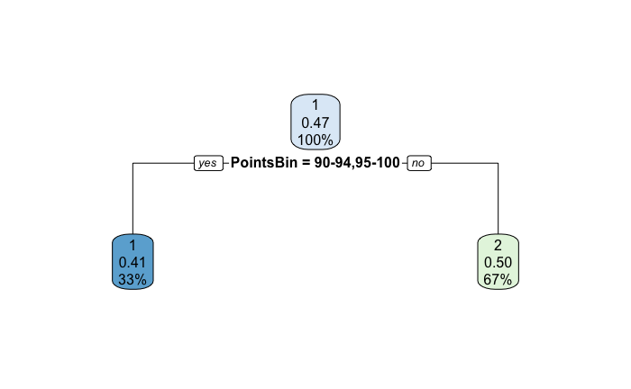

```r
rpart.plot(fit11, uniform = TRUE)
```

Length of clusters2.

```r
Vector1 <- as.numeric(as.character(WMDT$points))
length(Vector1[Vector1 >= 90])
```

```
[1] 32287
```

```r
nrow(clusters2[clusters2$Cluster == 1,] )
```

```
[1] 48411
```

```r
48411/97851
```

```
[1] 0.494742
```

```r
32287/97851
```

```
[1] 0.3299609
```

Attempt to create a decision tree using party package ctree.

```r
start.time <- Sys.time()
fitctree <- ctree(clusters ~ price + region, data = WMDT22)
time.taken <- Sys.time() - start.time
cat("Duration", time.taken, " seconds")
```

```
Duration 14.39248  seconds
```

Make a plot.

[figure not shown]

```r
ctreeplot <- plot(fitctree)
```